# Lecture_5 slides

## Занятие 5

### Summary

### Ревью ДЗ №1

### Задача 1. Ладьи

Пункт а)

- $P =\dfrac{\text{Кол-во расстановок, когда n ладей не бьют друг друга}}{\text{Общее число расстановок}} = \dfrac{M}{N}$
- $N = C_{n^2}^n = \dfrac{n^2!}{n!\cdot(n^2 - n)!}$
- $M = n!$
- $P = \dfrac{(n!)^2 \cdot (n^2 - n)!}{n^2!}$

Пункт б)

- Нужно использовать формулу включений-исключений!

### Пример

В классе 40 человек знает английский, 20 - немецкий, 25 - французский, 14 А + Н, 12 А+Ф, 10 Н + Ф, 4 А+Н+Ф. В классе 60 человек. Сколько человек не знают ничего?

Пусть $A_1$ - 1-я ладья на главной диагонали, $A_2$ - 2-я ладья на главной диагонали, ... , $A_1 \cap A_2$ - 1 и 2-я ладьи на главных диагоналях ...

$\bar{A}_1$ - 1-я ладья на главной диагонали, $\bar{A}_2$ - 2-я ладья на главной диагонали, ...

$$N(\bar{A_1}, ..., \bar{A_n}) = N - N(A_1) - ... - N(A_N) + N(A_1, A_2) + ... + N(A_N, A_{N-1}) - ... +(-1)^N N(A_1, ..., A_N) $$

**Формула включений-исключений** https://ru.wikipedia.org/wiki/%D0%A4%D0%BE%D1%80%D0%BC%D1%83%D0%BB%D0%B0_%D0%B2%D0%BA%D0%BB%D1%8E%D1%87%D0%B5%D0%BD%D0%B8%D0%B9-%D0%B8%D1%81%D0%BA%D0%BB%D1%8E%D1%87%D0%B5%D0%BD%D0%B8%D0%B9

Пункт б)

- Нужно использовать формулу включений-исключений!
- $N(A_1) = (n-1)!$
- $N(A_1, A_2) = (n-2)!$
- ...
- $\displaystyle \sum_{k=0}^N \frac{(-1)^k}{k!} \approx e^{-1}$

### Задача 2 ("шестигранный кубик")

- $P(A|B) = \dfrac{P(A \cap B)}{P(B)} = \dfrac{P(A)}{P(B)}$, почему?
- нужно правильно посчитать вероятности событий $P(B) = P(\{\text{хотя бы ...}\})$
- легче посчитать вероятность отрицания такого событий и $P(B) = 1 - P(\bar{B})$

### Задача 3 ("Возраст")

- $P(A|B) = \dfrac{P(A \cap B)}{P(B)} = \dfrac{P(A)}{P(B)}$
- на этом всё

### Задача 4 ("Качественная обувь")

- а) нужно было найти вероятность качественной обуви, а не наоборот!
- б) тут событие $P(\text{модель 2 типа | некачественная обувь})$
- используем формулу Байеса (здесь почти как формула условной вероятности)

### Задача 5 ("Распределение Пуассона")

- Результат выпадения симметричного шестигранного кубика.
- Количество людей в очереди на кассу в супермаркете.
- Количество изюма в булочках с изюмом.
- Число попаданий в баскетбольное кольцо за $n$ попыток.
- Точное время прихода на работу.
- равномерное
- Пуассона
- Пуассона
- биномиальное
- нормальное

### Задача 6 ("Распределения")

- не рисуйте на одном графике плотность и функцию распределения (в задании имелось в виду другое)
- подписывайте title, указывая распределение и функцию
- используйте \$ \$ для параметров (если нужно) в легенде

## А вообще было много хороших работ и красивых ноутбуков - спасибо, молодцы!

## Обсуждаем hw2 онлайн

### p-value

#### Разоблачения

- p-value $\ne P\{H_0 \text{ верна }\} $

Если $H_0$ верна, то с вероятностью $p$ произойдет наше событие

- Если $0.05 < p_1 < p_2$, то из этого не следует, что гипотеза с $p_2$ вероятнее, чем с $p_1$
- Если $p =0.3 > 0.05$, то из этого не следует, что она верна. Следует, что мы ее не отвергаем на данном этапе

Про $p-value$ и не только простым языком https://habr.com/ru/company/stepic/blog/250527/

### Проверка принадлежности распределению

- Критерий Колмогорова-Смирнова https://ru.wikipedia.org/wiki/%D0%9A%D1%80%D0%B8%D1%82%D0%B5%D1%80%D0%B8%D0%B9_%D1%81%D0%BE%D0%B3%D0%BB%D0%B0%D1%81%D0%B8%D1%8F_%D0%9A%D0%BE%D0%BB%D0%BC%D0%BE%D0%B3%D0%BE%D1%80%D0%BE%D0%B2%D0%B0
- Критерий Шапиро-Уилка (проверка на нормальность) http://www.machinelearning.ru/wiki/index.php?title=%D0%9A%D1%80%D0%B8%D1%82%D0%B5%D1%80%D0%B8%D0%B9_%D0%A8%D0%B0%D0%BF%D0%B8%D1%80%D0%BE-%D0%A3%D0%B8%D0%BB%D0%BA%D0%B0
- Критерий омега-квадрат http://www.machinelearning.ru/wiki/index.php?title=%D0%9A%D1%80%D0%B8%D1%82%D0%B5%D1%80%D0%B8%D0%B9_%D0%BE%D0%BC%D0%B5%D0%B3%D0%B0-%D0%BA%D0%B2%D0%B0%D0%B4%D1%80%D0%B0%D1%82

### Визуализация

- Большой пост об этом на примере pandas https://habr.com/ru/company/ods/blog/323210/

### z-значение (см занятие №3)

Любое распределение можно преобразовать в шкалу, где $M_z = 0$, a $D_z = 1$

$$z = \frac{X_i - \bar{X}}{\sigma}$$

Легко проверить, что такая случайная величина будет иметь среднее значение 0 и дисперсию 1.

### T-test

- Односторонний t-test (ttest_1samp)

$$t = \frac{\bar{X} - M}{SE}$$

Гипотеза $H_0: M_{X} = M^0$

- Двусторонний t-test (ttest_ind)

$$t = \dfrac{(\bar{X_1} - \bar{X_2}) - (M_1 - M_2)}{ \sqrt{\frac{s_1^2}{n_1} + \frac{s_2^2}{n_2}}} = \dfrac{\bar{X_1} - \bar{X_2}}{ \sqrt{\frac{s_1^2}{n_1} + \frac{s_2^2}{n_2}}} $$

Гипотеза $H_0: M_{X} = M_{Y} $

- тут не про зависимость случайных величин

### Эмпирическая функция распределения (см занятие №2)

Если мы знаем, что $X_1$ - непрерываное распределения со значениями, тогда оценим функцию распределения:

$$\bar{F_n}(x) = \frac{1}{n} \sum_{i=0}^n [X_i \le x]$$

Функция $\bar{F_n}(x)$ называется **эмпирической функцией распределения**

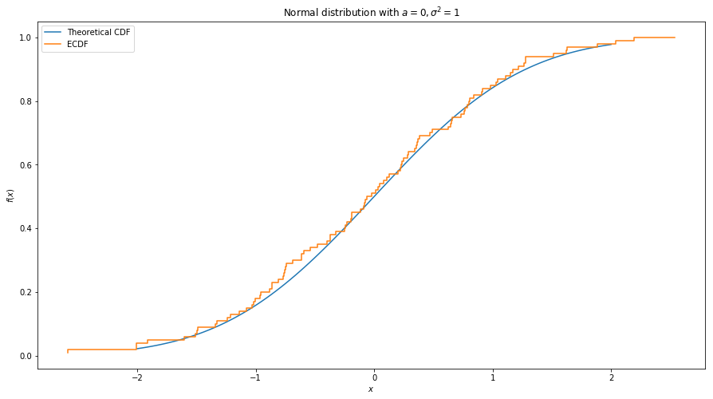

```python
norm_rv = sts.norm(0, 1)
sample = norm_rv.rvs(100)

x = np.linspace(-2,2,100)
cdf = norm_rv.cdf(x)

plt.figure(figsize=(15,8))
plt.plot(x, cdf, label='Theoretical CDF')

# для построения ECDF используем библиотеку statsmodels
from statsmodels.distributions.empirical_distribution import ECDF
ecdf = ECDF(sample)
plt.step(ecdf.x, ecdf.y, label='ECDF')

plt.title("Normal distribution with $a=0, \sigma^2=1$")
plt.ylabel('$f(x)$')
plt.xlabel('$x$')
plt.legend(loc='upper left')
```

### Что дальше?

- Статистика и котики https://www.labirint.ru/books/638687/
- Основы статистики https://stepik.org/course/76/syllabus
- Наглядная математическая статистика https://www.litres.ru/m-b-lagutin-6593695/naglyadnaya-matematicheskaya-statistika-uchebnoe-posobie-6713832/